# Layers descriptions

# Adjusted workforce size

#### (le_workforcesize_adj)

Data for total labor force (number of people) was obtained from the World Bank (data.worldbank.org/indicator/SL.TLF.TOTL.IN). The World Bank defines total labor force based on the International Labour Organisation (ILO)’s definition of an economically active population – those 15 years old and older who can supply labor for the production of goods and services – and includes those employed and unemployed, as well as those in the armed forces, and generally excludes homemakers and other unpaid caregivers and workers in the informal sector. For the three EEZs that fall within the China region (China, Macau, and Hong Kong), we combined the values by summing.

#### Units

number of jobs

# Adjustment factor for jobs (most current value)

#### (le_jobs_cur_adj_value)

See le_jobs_sector_year layer for more information about data and methods.

Percent employment during the current status year for each sector/region, calculated as (1 - percent unemployment)*total labor force (World Bank). This value was used to adjust the number of jobs by dividing the number of jobs by this value in the corresponding year.

#### Units

value

# Adjustment factor for jobs (reference period)

#### (le_jobs_ref_adj_value)

See le_jobs_sector_year layer for more information about data and methods.

Percent employment during the reference year (i.e., earliest year of data) for each sector/region, calculated as (1 - percent unemployment)*total labor force (World Bank). This value was used to adjust the number of jobs by dividing the number of jobs by this value in the corresponding year.

#### Units

value

# Adjustment factor for revenue (most current value)

#### (le_rev_cur_adj_value)

See le_rev_sector_year layer for more information about data and methods.

GDP during the current status year of each sector/region (World Bank). Revenue values for each sector/region were adjusted by dividing by GDP in the corresponding year of the sector/region current data.

#### Units

value

# Adjustment factor for revenue (reference period)

#### (le_rev_ref_adj_value)

See le_rev_sector_year layer for more information about data and methods.

GDP during the reference year (i.e., earliest year of data) of each sector/region (World Bank). Revenue values for each sector/region were adjusted by dividing by GDP in the corresponding year of the sector/region reference data.

#### Units

value

# Adjustment factor for wages (most current value)

#### (le_wage_cur_adj_value)

See le_wage_sector_year layer for informationa about data and methods.

The adjustment for each sector/region is 1, all adjustments were made in directly to the data layers.

#### Units

value

# Adjustment factor for wages (reference period)

#### (le_wage_ref_adj_value)

See le_wage_sector_year layer for informationa about data and methods.

The adjustment for each sector/region is 1, all adjustments were made in directly to the data layers.

#### Units

value

# Areas of blast fishing

#### (np_blast)

These data are from Reefs at Risk Revisited (Burke et al. 2007) and describe the prevalence of blast fishing.

See fp_art_hb for description of data and methods.

#### Units

score

# Areas of poison fishing

#### (np_cyanide)

These data are from Reefs at Risk Revisited (Burke et al. 2007) and describe the prevalence of poison fishing.

See fp_art_hb for description of data and methods.

#### Units

score

# Artisanal fisheries opportunity & management effectiveness

#### (ao_access)

This layer represents the opportunity for artisanal and recreational fishing in each country based on the quality of management of the smallscale fishing sector. Global data were extracted from Mora et al. (2009), Figure S4. Figure S4 is based on two expert opinion survey questions related to artisanal and recreational fishing (classified as small-scale fishing; presented in Table S5). Overall scores for small-scale fisheries management for each country are based on a scale of 0 to 100, with higher scores representing better management of the artisanal and recreational fishing sectors. These values were then rescaled (using a maximum value of 100 and minimum value of 0) to give a country score between 0 and 1 for each OHI region.

Questions from Mora et al. that were used to evaluate access to artisanal scale fishing.

If recreational fishing exists to any extent, which of the following apply: - Are recreational fishermen required to have a fishing license? Y/N - Are there regulations to the size of fish caught? Y/N - Are there regulations to the number of fish caught? Y/N - Are there regulations to the number of fishermen allowed to fish? Y/N - Are there statistics being collected for this sort of fishing? Y/N

If artisanal fishing exists to any extent, which of the following apply? - Are there regulations to the size of fish caught? Y/N - Are there regulations to the number of fish caught? Y/N - Are there regulations to the number of fishermen allowed to fish? Y/N - Are there statistics being collected for this sort of fishing? Y/N

#### Units

scaled 0-1

# Artisanal fisheries opportunity & management effectiveness

#### (fp_mora_artisanal)

See ao_access data layer for information about data and methods.

#### Units

scaled 0-1

# Average species condition

#### (spp_status)

See Species goal for calculations.

This value reflects the average condition of species (based on risk status from the IUCN Red List of Threatened Species, http://www.iucnredlist.org/) located within the eez of each region based on IUCN (shapefiles, used preferentially) and Aquamaps (http://www.aquamaps.org/, half degree resolution rasters) range maps.

#### Units

status score

# Average species condition trend

#### (spp_trend)

See Species goal for calculations.

This value reflects the average trend of species (based on trend status from the IUCN Red List of Threatened Species, http://www.iucnredlist.org/) located within the eez of each region based on IUCN (shapefiles, used preferentially) and Aquamaps (http://www.aquamaps.org/, half degree resolution rasters) range maps.

#### Units

trend score

# B/Bmsy estimates

#### (fis_b_bmsy)

For this current assessment we replaced this approach with estimates of B/BMSY, the ratio of population abundance compared to the abundance required to deliver maximum sustainable yield, obtained from the catch-MSY model (Martell and Froese, in press, see the Fisheries sub-goal description for Food Provision for more details). Although both approaches use similar empirically-derived relationships on depletion levels, the current model uses more information contained in the annual catch data and produces estimates that take into account how species with different life-history traits have different levels of resilience to fishing exploitation. An important difference from the previous approach is that the output is an index on a continuous scale, and management frameworks differ in how they define what range of B/BMSY constitutes an “overfished” status, or a “depleted” status, etc. For details on how the values are converted to a score on a scale from 0 to 1, see proportion of the Fisheries sub-goal description for Food Provision. Previously stock status was only used as a sustainability coefficient for Fish Oil in the Natural Products goal; it is now an integral part of how the Fisheries sub-goal in Food Provision goal is calculated.

#### Units

B/Bmsy

# Carbon storage weights

#### (element_wts_cs_km2_x_storage)

This layer describes the relative value of the habitats to the carbon storage goal in each region. These data are called internally by ohicore functions (see: conf/config.R to see how these data are specified) to weight the the data used to calculate pressure and resilience values. These data are created by multiplying habitat extent by the amount of carbon the folllowing habitats sequester (Laffoley & Grimsditch 2009): mangrove (offshore and inland 1km), saltmarsh, and seagrass.

#### Units

extent*storage

# Chemical pollution

#### (po_chemicals)

This pressure layer is calculated using data for land-based organic pollution (pesticide data), land-based inorganic pollution (using impermeable surfaces as a proxy), and ocean pollution (shipping and ports). These global data are provided at ~1km resolution, with values scaled from 0-1 (Halpern et al. 2008, 2015). To obtain the final pressure values, the three raster layers were summed (with cell values capped at <= 1).

#### Land-based organic pollution

Data were calculated using modeled plumes of land-based pesticide pollution that provide intensity of pollution at 1km2 resolution (Halpern et al. 2008).

Organic pollution was estimated from FAO data on annual country-level pesticide use (http://faostat3.fao.org/faostat-gateway/go/to/browse/R/*/E), measured in metric tons of active ingredients. FAO uses survey methods to measure quantities of pesticides applied to crops and seeds in the agriculture sector, and includes insecticides, mineral oils, herbicides, fungicides, seed treatments insecticides, seed treatments fungicides, plant growth regulators and rodenticides. Missing values were estimated by regression between fertilizer and pesticides (see chemical pollution: land-based organic, described above) when possible, and when not possible with agricultural GDP as a proxy. Data were summed across all pesticide compounds and reported in metric tons. Upon inspection the data included multiple 0 values that are most likely data gaps in the time-series, so they were treated as such and replaced with NA. In addition, regions with only 1 data point and regions where the most recent data point was prior to 2005 were excluded. The data gaps were then filled using coastal population trends for the corresponding reporting region. Uninhabited countries were assumed to have no pesticide use and thus excluded.

These country-level pollution values were then dasymetrically distributed over a country’s landscape using global landcover data from the years 2005 (for the 2003-2006 time period) and 2009 (for the 2007-2010 time period), derived from the MODIS satellite at ~500m resolution. These values were then aggregated by ~140,000 global basins, and diffusive plumes were modeled from each basin’s pourpoint. The final non-zero plumes (about ~76,000) were aggregated into ~1km Mollweide (wgs84) projection rasters to produce a single plume-aggregated pollution raster.

These raw values were then ln(X+1) transformed and normalized to 0-1 by dividing by the 99.99th quantile of raster values across all years. The zonal mean was then calculated for each region.

#### Land-based inorganic pollution

These data are from Halpern et al. (2008, 2015), and available from Knowledge Network for Biocomplexity (KNB, https://knb.ecoinformatics.org/#view/doi:10.5063/F19021PC, rescaled_2013_inorganic_mol). Non-point source inorganic pollution was modeled with global 1 km2 impervious surface area data (http://www.ngdc.noaa.gov/dmsp/) under the assumption that most of this pollution comes from urban runoff. These data will not capture point-sources of pollution or nonpoint sources where paved roads do not exist (e.g., select places in developing countries). Third, values for these three anthropogenic drivers were then aggregated to the watershed and distributed to the pour point (i.e., stream and river mouths) for the watershed with raster statistics (i.e., aggregation by watershed).

#### Ocean pollution (shipping lanes, ports)

These data are from Halpern et al. (2015), and available from the Knowledge Network for Biocomplexity (KNB, https://knb.ecoinformatics.org/#view/doi:10.5063/F1DR2SDD, rescaled_2013_one_ocean_pollution_mol). Ocean-based pollution is assumed to derive from commercial and recreational ship activity and combines commercial shipping traffic data (see Commercial Activity) and port data (see Invasive Species).

Shipping data was obtained from two sources: (1) Over the past 20 years, 10-20% of the vessel fleet has voluntarily participated in collecting meteorological data for the open ocean, which includes location at the time of measurement, as part of the Volunteer Observing System (VOS). (2) In order to improve maritime safety, in 2002 the International Maritime Organization SOLAS agreement required all vessels over 300 gross tonnage (GT) and vessels carrying passengers to equip Automatic Identification System (AIS) transceivers, which use the Global Positioning System (GPS) to precisely locate vessels.

Port data was obtained from using the volume (measured in tonnes) of goods transported through commercial ports as a proxy measure of port traffic. Total cargo volume data by port was collected from regional and national statistical organizations, and from published port rankings.

#### Units

scaled 0-1

# Chemical pollution trend

#### (cw_chemical_trend)

See description for chemical pollution layer [po_chemicals].

The inverse of the pressure data (1 - value) from the po_chemicals layer (including only the 3nm offshore region) was used to estimate chemical trends for the clean water goal. The proportional yearly change in chemical pressure values were estimated using a linear regression model of the most recent five years of data (i.e., slope divided by data from the earliest year included in the regression model). The slope was then multiplied by five to get the predicted change in 5 years.

The only layer with yearly data was the land-based organic pollution (pesticide data). The land-based inorganic pollution (using impermeable surfaces as a proxy) and ocean pollution (shipping and ports) remained the same.

#### Units

trend

# CITES signatories

#### (g_cites)

These data are from the Convention on International Trade in Endangered Species of Wild Fauna and Flora (CITES) and list the contracting parties to the convention (http://www.cites.org/eng/ disc/parties/alphabet.php). The Convention is an international agreement between governments that aims at ensuring that any international trade in plants and animals “does not threaten their survival.” All countries party to the Convention are given full credit for membership; those countries that are not contracting parties are given no credit (score = 0).

#### Units

scaled 0-1

# Coastal chemical pollution

#### (po_chemicals_3nm)

See description for chemical pollution layer [po_chemicals].

Methods follow those described for the po_chemicals layer. However, the rescaled data were clipped to include only the pixels within 3nm offshore, and the zonal mean for each region was calculated from these data.

For the clean waters goal calculations, the inverse of these pressure values are used (1 minus chemical pressure).

#### Units

scaled 0-1

# Coastal nutrient pollution

#### (po_nutrients_3nm)

See description for nutrient pollution layer [po_nutrients].

Methods follow those described for the po_nutrients layer. However, the rescaled data were clipped to include only the pixels within 3nm offshore, and the zonal mean for each region was calculated from these data.

For the clean waters goal calculations, the inverse of these pressure values are used (1 minus nutrient pressure).

#### Units

scaled 0-1

# Coastal protected marine areas

#### (fp_mpa_coast)

This resilience score (values ranging from 0-1) is calculated using the lasting special places status subgoal model. The total marine protected area (km2) within 3 nm offshore is determined (see the lsp_prot_area_offshore3nm data layer for information about the data). Following to the lasting special places model, a reference point of 30% is used, such that any region with 30%, or more, protected area receives a score of 1.

#### Units

scaled 0-1

# Coastal protected marine areas

#### (hd_mpa_coast)

See fp_mpa_coast for information about this layer.

#### Units

scaled 0-1

# Coastal protection weights

#### (element_wts_cp_km2_x_protection)

This layer describes the relative value of the habitats to the coastal protection goal in each region. These data are called internally by ohicore functions (see: conf/config.R to see how these data are specified) to weight the the data used to calculate pressure and resilience values. These data are created by multiplying habitat extent by the habitat protection rank for: coral, mangrove (offshore and inland 1km), sea ice (shoreline), saltmarsh, and seagrass.

#### Units

extent*rank

# Commercial fishing management

#### (fp_mora)

These data come from Mora et al. (2009), and assess the current effectiveness of fisheries management regimes along 6 axes: Scientific Robustness, Policy Transparency, Implementation Capacity, Subsidies, Fishing Effort, and Foreign Fishing. All countries with coastal areas were assessed through a combination of surveys, empirical data and enquiries to fisheries experts. For each OHI reporting region, scores for each category were rescaled between 0 and 1 using the maximum possible value for each category and then the average score of all 6 categories combined was recorded as the overall Fisheries management effectiveness score.

#### Units

scaled 0-1

# Economic diversity

#### (li_sector_evenness)

Sector evenness was measured using Shannon’s Diversity Index, a common measure of ecological and economic diversity that has been applied previously to economic sectors. This calculation is based on the total number of sectors and the probability that any given job belongs to a sector.

#### Units

scaled

# Economic need for artisanal fishing

#### (ao_need)

The need for artisanal fishing opportunities is measured as Purchasing Power Parity adjusted per capita Gross Domestic Product (ppppcgdp) in “constant” USD (World Bank, http://data.worldbank.org/indicator/NY.GDP.PCAP.PP.KD). Gross Domestic Product (gdp) was obtained in US dollars from The World Bank. The World Bank defines gdp as the gross value of all resident producers in the economy plus product taxes and minus and subsidies not included in the value of the products. The gdp was then adjusted by population size to get per capita output and by Purchasing Power Parity (ppp) to account for the difference in exchange rates between countries. These values are then rescaled to have values between zero and one by taking the natural log of the values and then dividing by the 99th quantile value across all years/regions (2005 to most recent year).

When a region is missing some year’s of data, a within region linear model is used to estimate these missing years (2005 to current year).

The artisanal opportunities model assesses need as 1 minus ppppcgdp.

#### Units

scaled 0-1

# EEZ protected marine areas

#### (fp_mpa_eez)

This resilience score (values ranging from 0-1) is calculated using the lasting special places status subgoal model (except this calculation is based on the entire eez region vs. 3 nm offshore). The total marine protected area (km2) within the offshore eez region is determined (see the lsp_prot_area_offshore3nm data layer for information about the data). Following to the lasting special places model, a reference point of 30% is used, such that any region with 30%, or more, protected area receives a score of 1.

#### Units

scaled 0-1

# EEZ protected marine areas

#### (hd_mpa_eez)

See fp_mpa_eez for information about this layer.

#### Units

scaled 0-1

# Fishery catch data

#### (fis_meancatch)

2012 Supplement: Fisheries catch data come from FAO global fisheries catch statistics, data from international and national fisheries agencies, and reconstructed catch datasets that have been spatialized to half-degree resolution in WGS84 geographic projection by the Sea Around Us Project31 and then aggregated to each reporting region. All gaps in catch reporting were treated as true zeros; six countries had poor data reporting for early years in the time series and so these were treated as zeros (Bahamas, Dominican Republic, Kenya, Sudan, Mozambique, and South Georgia & Sandwich Islands). We used data from 2006 as the current estimate because they are the most recent data spatialized by the Sea Around Us Project. During rasterization, cells that spanned an EEZ boundary were allocated to the EEZ proportional to the area of the cell within the EEZ. When more than one EEZ fell within a single one of our reporting units, we calculated a weighted average based on the relative area in the particular EEZ. We smoothed annual catch data for each species using a 4-year moving window average and then summed values across all species to get the total catch for each year during 1953-2006. Smoothed values were used instead of raw reported values to reduce potential bias from values that change due to changes in reporting rather than actual changes in landings. For example, we found anomalous values in Mediterranean European countries in 2005 that were due to changes in how data were reported.

#### Units

tonnes

# Food provision weights

#### (fp_wildcaught_weight)

To weight the relative contributions of fisheries and mariculture to the food provision goal, we calculate the tonnes of fisheries production (SAUP data, Zeller and Pauly 2007) relative to the total tonnes of food production from fisheries and mariculture (FAO data, FAO Global Aquaculture Production Quantity).

#### Units

proportion

# GDP

#### (le_gdp)

National GDP data were obtained from the World Bank (http://data.worldbank.org/indicator/ NY.GDP.MKTP.CD) and converted into 2010 USD from current USD. These data were used in livelihood and economy goals to adjust revenue data. For the three EEZs that fall within the China region (China, Macau, and Hong Kong), we combined the values using a population-weighted average.

# GDP

#### (le_revenue_adj)

National GDP data were obtained from the World Bank (http://data.worldbank.org/indicator/ NY.GDP.MKTP.CD) and converted into 2010 USD from current USD. These data were used in economy subgoal to adjust revenue data. For the three EEZs that fall within the China region (China, Macau, and Hong Kong), we combined the values using a population-weighted average.

#### Units

USD

# GDP per capita PPP

#### (le_gdp_pc_ppp)

See ao_need layer for details.

#### Units

USD

# Genetic escapes

#### (sp_genetic)

This layer represents the potential for harmful genetic escapement based on whether the species being cultured is native or introduced. Data come from the Mariculture Sustainability Index (MSI, Trujillo 2008). In the MSI analysis native species receive the highest score (10), while foreign and introduced species receive the lowest (1) on the premise of potential impacts to local biodiversity if these species were to escape. Use of native but non-local species were scored intermediately based on the assumption that potentially negative alterations to genetic biodiversity occur from non-local sources as well, but to a lower degree. Genetic ‘pollution’ can arise when larvae, spats or seeds escape from poorly managed hatcheries, making native species vulnerable to outbreeding depressions and/or genetic bottlenecks. The MSI reports data for 359 country-species combinations (with 53 countries represented). Where multiple scores exist for a country the weighted average of all scores (0-10) is used. All country scores were then rescaled from 0 to 1, using the maximum raw score of 10 and minimum of 1. Countries that were not analyzed by Trujillo did not receive a score and this pressure layer falls out of their analyses.

#### Units

scaled 0-1

# Global Competitiveness Index (GCI) scores

#### (li_gci)

The World Economic Forum’s Global Competitiveness Index (GCI) provides a country level assessment of competitiveness in achieving sustained economic prosperity (Schwab 2011, http://gcr.weforum.org). The GCI is a weighted index based on 12 pillars of economic competitiveness: institutions, infrastructure, macroeconomic environment, health and primary education, higher education and training, goods market efficiency, labor market efficiency, financial market development, technological readiness, market size, business sophistication, and innovation. The GCI can in theory span from 1 to 7, so we rescaled the scores to a 0 to 1 scale based on this range.

#### Units

scaled

# Habitat condition

#### (hab_health)

See hab_extent layer for more information.

#### Coral

Condition was calculated using current condition data divided by reference condition. We use condition data from percent live coral cover from 12,634 surveys from 1975-2006 (Bruno and Selig 2007, Schutte et al. 2010). When multiple data points are available for the same site and year, we average these data, and also average the site data to calculate a per country per year average. However, data were missing for several countries and some countries did not have data for the reference or current year time periods or had only 1-2 surveys. Because coral cover can be highly temporally and spatially dynamic, having only a few surveys that may have been motivated by different reasons (i.e., documenting a pristine or an impacted habitat) can bias results. To calculate condition we used fitted values from a linear trend of all data per country, which was more robust to data poor situations and allowed us to take advantage of period of intense sampling that did not always include both current and reference years. Then, we create a fitted linear model of all these data points in 1975-2010, provided that 2 or more points are in 1980-1995 and 2 or more points are in 2000-2010. We defined the ‘current’ condition (health) as the mean of the predicted values for 2008-2010, and the reference condition as the mean of the predicted values for 1985-1987. Where country data were not available, we used an average from adjacent EEZs weighted by habitat area, or a georegional average weighted by habitat area, based on countries within the same ocean basin (Figure).

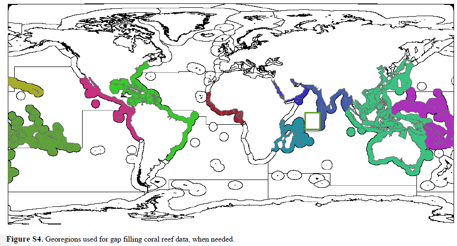

#### Mangroves

Condition was the current cover divided by reference cover. FAO mangrove area data was provided on a country basis for 1980, 1990, 2000, and 2005. Current condition is based on 2005 cover, and reference condition is based on the 1980 cover.

#### Salt marsh

Condition was assigned based on trend, for regions where both a current and reference data year available. An increasing or stable trend was assigned condition = 1.0, and decreasing trend was assigned condition = 0.5. Data was from multiple sources (Bridgham et al. 2006, Dahl 2000, Ministry for the Environment 2007, JNCC 2004, EEA 2008).

#### Sea ice

Sea ice condition was calculated using sea ice concentrations from the USA National Snow and Ice Data Center (Cavalieri et al. 2014; https://nsidc.org/cryosphere/quickfacts/seaice.html) as the current percent cover of sea ice (average of 3 years of data) divided by the average historical percent cover, defined as the start of the data (1979) until the year 2000 as recommended by the National Snow & Ice Data Center (Cavalieri et al. 2014; https://nsidc.org/cryosphere/quickfacts/seaice.html) for each of the sea ice habitats.

#### Seagrass

Seagrass condition was calculated on a per-site basis from Waycott et al. (2009), which provides seagrass habitat extent data for several sites around the world over several years. Reference condition was calculated as the mean of the three oldest years between 1975-1985, or the two earliest years if needed. If data responding to these conditions was not available, we fitted a linear model to all data points, and then used the mean of the predicted values for 1979-1981 as the reference condition. For the current condition we used the mean of the three most recent years after 2000 or the two most recent years. If condition data satisfying these constraints were still not available, we fitted a linear model to all data points, provided that there were at least three data points and then used the mean of the predicted values for 2008-2010 as the current condition and the mean of the predicted values for 1979-1981 as the reference condition. Otherwise, we used neighboring (adjacent) regional averages, weighted by habitat area, or averages weighted by habitat area using seagrass geographical regions as defined by Hemminga and Duarte (2000). We did not project beyond a 15-year timeframe.

#### Soft-bottom subtidal

To estimate status of this habitat, we used intensity of trawl fishing relative to soft-bottom subtidal habitat as a proxy. Spatialized catch data (0.5 degree raster) are available from the global catch database of the Sea Around Us project, which uses data from FAO global fisheries catch statistics, data from international and national fisheries agencies, and reconstructed catch datasets (Zeller and Pauly 2007). The proportion of catch by fishing gear type was estimated at 0.5 degree resolution based on global taxon-gear associations (Watson et al. 2006a,b, Halpern 2008). These data were used to calculate catch (tonnes per year) from trawling for each year. Trawling gears were defined as dredges, hand dredges, bottom trawls, and shrimp trawls (mid-water trawls were excluded). These catches were assumed to be uniform within each half degree cell. We aggregated by summing the trawled catch data by reporting region for each year, and converted to catch density by dividing annual catch by the trawlable (soft-bottom) habitat. ‘Trawlable habitat’ within a region was defined as shallow subtidal (0-60m) and outer shelf (60-200m) soft bottom habitat. Because these data were extremely skewed, we ln(X+1) transformed them and then rescaled to the 95th quantile value from all year-country possibilities. Condition was then calculated as one minus the rescaled catch density in the most recent year. The condition value was then rescaled to the median intensity density value across all years, and any value greater than the median was set = 1.0.

#### Units

proportion

# Habitat condition trend

#### (hab_trend)

See hab_extent layer for more information.

#### Coral

Trend was calculated using condition data from 1975-2006. Condition data was estimated as percent live coral cover based on 12,634 surveys from 1975-2006 (Bruno and Selig 2007, Schutte et al. 2010). When multiple data points are available for the same site and year, we average these data, and also average the site data to calculate a per country per year average. However, data were missing for several countries and some countries did not have data for the reference or current year time periods or had only 1-2 surveys. Because coral cover can be highly temporally and spatially dynamic, having only a few surveys that may have been motivated by different reasons (i.e., documenting a pristine or an impacted habitat) can bias results. To calculate Ck we used fitted values from a linear trend of all data per country, which was more robust to data poor situations and allowed us to take advantage of period of intense sampling that did not always include both current and reference years. Then, we create a fitted linear model of all these data points in 1975-2010, provided that 2 or more points are in 1980-1995 and 2 or more points are in 2000-2010. Where country data were not available, we used an average from adjacent EEZs weighted by habitat area, or a georegional average weighted by habitat area, based on countries within the same ocean basin.

#### Mangroves

We used Hamilton and Casey’s (2014) mangrove cover data to estimate the proportional yearly change in mangrove area using a linear regression model of the most recent five years of data (i.e., slope divided by data from the earliest year included in the regression model). The slope was then multiplied by five to get the predicted change in 5 years. The orgiginal mangrove data are provided yearly (2000-2012) at 30m raster cell resolution (with the estimated area of mangrove cover in each cell).

#### Salt marsh

Annual change rates in habitat area were calculated from 1994-2007, where available, using data from multiple sources (Bridgham et al. 2006, Dahl 2000, Ministry for the Environment 2007, JNCC 2004, EEA 2008). For Trend estimates, we extracted categorical condition data (‘increasing”, “stable”, “declining” score as 0.5, 0.0, and -0.5, respectively) from these sources on a per country basis for countries where both a current and reference data year available.

#### Sea ice

Sea ice trend was calculated using sea ice concentrations from the USA National Snow and Ice Data Center (Cavalieri et al. 2014; https://nsidc.org/cryosphere/quickfacts/seaice.html). The average yearly proportional change in extent was estimated with a linear regression model that included the most recent five years of data (e.g., slope estimate was divided by the extent for earliest year included in the regression model), and this value was multiplied by five to get the predicted change in 5 years. Each year of data is a 3-year average, to smooth yearly variation, for the sea-ice habitats.

#### Seagrass

For trend in seagrass status we use two data sources (Waycott et al. 2009, Short et al. 2010). Short et al. (2010) measured percent cover on a per sample, per site, per year basis, whereas Waycott et al.(2009) measured habitat area on a per site, per year basis. We used data from Short if there were at least 3 data points between 2001-2010. If this condition was not met, we calculated trends from Waycott for the most recent 10 years after 1990 or else we used the mean of the trend in the adjacent regions or the regions within the corresponding seagrass geographical regions using the same methods described above for the in status.

#### Soft-bottom subtidal

Trend was estimated using the condition data (see hab_health). The average yearly change in condition was estimated with a linear regression model that included the most recent five years of data (e.g., slope estimate was divided by the extent for earliest year included in the regression model and then multiplied by five to get the 5 year estimate).

#### Units

trend

# Habitat extent

#### Table. Overview of the habitats used in different goal calculations

| Habitat | Habitat goal | Coastal Protection | Carbon Storage | Natural Products (exposure) |
| --- | --- | --- | --- | --- |
| Seagrass | X | X | X |  |
| Mangrove | X | X | X |  |
| Saltmarsh | X | X | X |  |
| Coral | X | X |  | X |
| Sea ice shoreline |  | X |  |  |
| Sea ice edge | X |  |  |  |
| Rocky reef |  |  |  | X |
| Soft-bottom subtidal | X |  |  |  |

#### Coral

Extent data are derived from the 500m resolution dataset developed for Reefs at Risk Revisited, and we calculate extent area using a resampled version of our EEZ regions to match their 500m resolution.

#### Mangroves

Hamilton and Casey’s (2014) yearly (2000-2012) mangrove cover data were used to calculate mangrove extent. Data were provided at 30m raster cell resolution (with the estimated area of mangrove cover in each cell), to facilitate global calculations of area (km2), we converted these data to 500m resolution.

#### Salt marsh

Salt marsh data per country come from multiple sources (Bridgham et al. 2006, Dahl 2000, Ministry for the Environment 2007, JNCC 2004, EEA 2008) and are generally reported as habitat area. In the case of Europe, most data were obtained via the European Environment Agency databases housing information pertaining to the European Union’s Habitat Directive.

Severe data gaps exist for several key regions of the world, including the Middle East, South America, and Africa. Extensive salt marshes are believed to exist in the Middle East, bordering the unique salt flat ecosystems known as sabkha, however no numbers concerning extent could be found. Similarly, data on salt marshes in South America were extremely limited, with no estimates on current rates of loss or historical extent from or before the 1970s. The majority of the data included in the model come from North America (United States and Canada), Australia, New Zealand, China, Europe, and the United Kingdom.

#### Rocky reef

To create a data layer of global rocky reef habitat we used data created by Halpern et al. (2008) rocky reef intertidal data do not exist globally so rocky reef habitat was assumed to exist in all cells within 1 km of shore globally.

#### Sea ice

Sea ice extent was calculated using sea ice concentrations from the USA National Snow and Ice Data Center (Cavalieri et al. 2014; https://nsidc.org/cryosphere/quickfacts/seaice.html), which are updated yearly. These raster data are 25km in resolution (625km2 per pixel) in a Stereographic polar projection. Two sea ice metrics are calculated using these data: sea-ice edge and sea ice shoreline (shoreline pixels with >15% ice cover). Calculations of area are based on 3-year averages (to smooth yearly variation, e.g., 2009 data is the average of 2008-2010) of the pixels meeting the habitat criteria.

#### Seagrass

Seagrass extent was calculated from vector-based data from the Global Distribution of Seagrasses (UNEP-WCMC 2005).

#### Soft-bottom subtidal

Soft-bottom habitat was defined as the total area of shallow (0-60m) and shelf (60-200m) soft-bottom habitat within the reporting region based on benthic substrate point samples (Halpern et al. 2008).

#### Units

km2

# Habitat weights

#### (element_wts_hab_pres_abs)

This layer describes the habitats present in each region and is called internally by ohicore functions (see: conf/config.R to see how these data are specified) to calculate pressure and resilience values based on the habitats present in each region. These data are created from the hab_extent data layer.

#### Units

boolean

# High bycatch due to artisanal fishing

#### (fp_art_hb)

Reefs at Risk Revisited (Burke et al. 2007) recorded the presence of destructive artisanal blast and poison (cyanide) fishing in a country based on survey observations and expert opinion. For reclassified the log-scale scoring system for the blast and poison rasters, so 0 = 0, 100 = 1, 1000 = 2. The mean raster score was then determined for each OHI region. The poison and blast values for each region were then summed to get the total.

A notable limitation of using these data as a proxy for high bycatch artisanal fishing is that they only cover coral reef habitats. High bycatch artisanal fishing likely exists in every coastal country on the planet, but we have no way of knowing the type or extent (for every country).

#### Units

scaled 0-1

# High bycatch due to commercial fishing

#### (fp_com_hb)

From OHI2105_methods_update_final: For this layer, we used updated Sea Around Us Project (SAUP) catch reconstruction data and new net primary productivity data. The new SAUP data were available only at the country scale and did not differentiate catch by gear type. To estimate high resolution catch data by gear type we used the original global (0.5 degree resolution) catch by gear spatial data provided by the SAUP for Halpern et al. (2008) to calculate the proportion of catch caught by high and low bycatch gears within each raster cell. The updated global catch from the Sea Around Us Project for the years 2006-2010 was summarized per EEZ and FAO region and then distributed across the respective region based on the proportion catch with each raster cell for high and low bycatch gear. This method assumes that proportion of catch per gear type has remained constant within a region, although absolute catch can change. The layer was then standardized by average net primary production (VGPM) over the same years, 2006 to 2010. Updating the NPP data had not been done previously. Data was log transformed and then normalized by using the 99.99th quantile.

#### Units

scaled 0-1

# Inland area

#### (rgn_area_inland1km)

Area (km2) located from each region’s land-sea interface to 1 km inland.

For coastal land (inland) areas, we extracted hi-resolution country boundary data from ESRI (2010), and rasterized it with a resolution to match our land-sea interface model. We grew this raster by 50 pixels to bridge gaps between the ESRI data and our land-sea model. The ESRI data have Taiwan as part of China, so we manually extracted the mainland of Taiwan to calculate land area. Area values do not include inland lakes or EEZs.

See rgn_area layer for more information.

#### Units

km2

# Inland coastal population

#### (mar_coastalpopn_inland25mi)

Coastal Population count was determined for each region using Gridded Population of the World (GPW) Population Count Grid Future Estimates (v3) from the Center for International Earth Science Information Net (CIESIN)/Columbia University (CIESIN & CIAT 2005). Global data were provided at 2.5 arc-minute resolution for 2005, 2010, and 2015. Years in between those provided were temporally interpolated. For instance, d2013 = 0.4 * d2010 + 0.6 * d2015. The total coastal population count data was calculated for each region by extracting the relevant cell data using a 25-mile inland coastal zone shapefile. Where modeled coastal population exceeded World Bank reported total population, World Bank figures were used. We used other sources (e.g., World Bank, Wikipedia, etc.) to estimate population for some island regions (Macquarie Island, Wake Island, Glorioso Islands, Juan de Nova Island, Bassas da India, Ile Europa, Ile Tromelin, British Indian Ocean Territory, Kerguelen Islands, Heard and McDonald Islands, Bouvet Island, Clipperton Island, Jan Mayen, Palmyra Atoll, Johnston Atoll, South Georgia and the South Sandwich Islands, Prince Edward Islands, Crozet Islands, Amsterdam Island and Saint Paul Island).

#### Units

number of people

# Inland coastal protected areas

#### (lsp_prot_area_inland1km)

This includes protected areas 1km inland, but otherwise follows the methods described in lsp_prot_area_offshore3nm.

#### Units

km2

# Intertidal habitat destruction

#### (hd_intertidal)

Coastal Population density was determined for each region using Gridded Population of the World (GPW) Population Count Grid Future Estimates (v3) from the Center for International Earth Science Information Net (CIESIN)/Columbia University (CIESIN & CIAT 2005). Global data were provided at 2.5 arc-minute resolution for 2005, 2010, and 2015. Years in between those provided were temporally interpolated. For instance, d2013 = 0.4 * d2010 + 0.6 * d2015. The total coastal population count data was calculated for each region by extracting the relevant cell data using a 25-mile inland coastal zone shapefile. Where modeled coastal population exceeded World Bank reported total population, World Bank figures were used. We used other sources (e.g., World Bank, Wikipedia, etc.) to estimate population for some island regions (Macquarie Island, Wake Island, Glorioso Islands, Juan de Nova Island, Bassas da India, Ile Europa, Ile Tromelin, British Indian Ocean Territory, Kerguelen Islands, Heard and McDonald Islands, Bouvet Island, Clipperton Island, Jan Mayen, Palmyra Atoll, Johnston Atoll, South Georgia and the South Sandwich Islands, Prince Edward Islands, Crozet Islands, Amsterdam Island and Saint Paul Island). Population count data was converted to average coastal density by dividing by the total 25 mile inland area. We then rescaled the data to have values between 0-1, by logging the density data and then dividing by the ln (maximum density) across all regions and years.

#### Units

scaled 0-1

# ISO country codes

#### (cntry_rgn)

Country codes for OHI regions based on ISO 3166 country codes.

#### Units

region id

# IUCN extinction risk

#### (ico_spp_iucn_status)

This data layer provides the risk category and the year the species was assessed from the IUCN Red List of Threatened Species (http://www.iucnredlist.org/) for the iconic species in each region. In some cases, we were able to use regionally specific IUCN status data for subpopulations.

The OHI global iconic species list was created by combining three species lists from WWF Global: global priorities, regional and local priorities, and flagship species. The criteria for including species within those WWF lists overlapped with key points from OHI’s definition of iconic species. OHI defines iconic species as species recognized as relevant to local cultural identity through the species’ relationship to traditional activities such as fishing, hunting, commerce or involvement in local ethnic or religious practices; and species with locally-recognized aesthetic value (e.g., touristic attractions/common artistic subjects such as whales). Habitat forming species were not included in this definition of iconic species. Lists were not used when the only criteria for species inclusion included that the species are impacted by human activities or have a threatened population status. Once the species lists were obtained, each species was assigned to a region based on range countries from the IUCN Red List. Additionally, national priority and flagship species lists were included for those specific countries only.

Most of the iconic species are not region specific (i.e., a global list was created that is applied to most regions). However, as more regional assessments are conducted (http://ohi-science.org/projects/), we will use the iconic species list developed by those countries/regions in our model.

#### Units

IUCN risk category

# Jobs for each sector and year

#### (le_jobs_sector_year)

This layer includes yearly data for jobs in commercial fishing, mariculture, marine mammal watching, marine renewable energy, and, tourism. The data sources and methods for each sector are described below.

#### Commercial fishing

Data come from the United Nations Food and Agriculture Organization (FAO) Fisheries and Aquaculture Department which provides a Global Number of Fishers (GNF) (http://www.fao.org/fishery/statistics/global-fishers/en.) The data contains yearly total numbers of employees in commercial fishing, subsistence fishing, and aquaculture (land- and ocean-based combined) in more than 160 countries. The dataset includes the following occupational categories: aquatic-life cultivation, inland waters fishing, marine coastal waters fishing, marine deepsea waters fishing, subsistence and unspecified. We omitted jobs with an unspecified category to avoid overestimating employment for marine fishing or aquaculture. We omitted jobs in the subsistence category since subsistence opportunities are captured by the artisanal fishing opportunity goal of the OHI and in the aquatic-life cultivation category since that represents a distinct sector (see mariculture below). For commercial fishing, we eliminated inland waters fishing and summed marine coastal waters and marine deep-sea waters fishing for each country in each year. Data are reported separately for men and women, but we summed these numbers. Employment is disaggregated into full-time, parttime, occasional, and unspecified statuses. These categories are defined as full time workers having > 90% of their time or livelihood from fishing/aquaculture, part time workers are between 30-90% time (or 30-90% of their livelihood) and occasional workers are < 30% time. Unspecified status workers could fall anywhere from 0-100% time. Taking the midpoints of those ranges, we assume that 1 part time worker = 0.6 full time workers, 1 occasional worker = 0.15 full time workers, and 1 unspecified worker = 0.5 full time workers, which we used as a weighting scheme for determining total numbers of jobs. The data also contain significant gaps, but they provide the most comprehensive source of global data on commercial fishing and aquaculture employment.

#### Mariculture

We used the FAO GNF dataset (see Marine jobs: commercial fishing above for full dataset description) to estimate jobs for mariculture. For this sector, we used data in the aquatic-life cultivation category. Again, employment is disaggregated into full-time, part-time, occasional, and unspecified statuses and we implement a weighting scheme where full time = 1 job, part-time = 0.6, occasional = 0.15, and unspecified = 0.5. Aquatic-life cultivation includes marine, brackish and freshwater aquaculture. In order to estimate the proportion of total aquaculture jobs that can be attributed to marine and brackish aquaculture, we used country-specific proportions of marine and brackish aquaculture revenues (compared to total revenues) calculated from FAO aquaculture production data (obtained from FishStat), assuming that numbers of jobs approximately scale with production in terms of revenue. For country-years where there were no data for the proportion of marine/brackish production because of gaps in the FAO production data, we used the proportion from the most recent year for which data were available. For countries for which we did not have proportion estimates from any years, we used the average proportion from the country’s geographic region (e.g., Caribbean, Polynesia, Eastern Asia), with the exception of American Samoa, for which we used the proportion value from Guam.

#### Marine mammal watching

The International Fund for Animal Welfare’s (IFAW) Whale Division provides time series data on whale watching in more than 115 coastal countries (O’Connor et al 2009). This dataset may be an imperfect representation of all marine mammal watching due to its focus on whales, although it does include data for other types of marine mammal watching (e.g., dolphins). However, to our knowledge, it is the most complete dataset pertaining to the global marine mammal watching industry. We obtained regional averages of the number of whale watchers per employee, as well as the number of whale watchers in each country. Using this information, we estimated the number of whale watching jobs in each country by dividing the country’s total number of whale watchers by the average number of whale watchers per employee for that country’s region (e.g., Africa & Middle East, Europe, North America). It is important to note that data are not annual, but there are at least four years of data for each country. When IFAW reported “minimal” numbers of whale watchers, we converted this description to a 0 for lack of additional information. Because some of the whale watching in O’Connor et al. focused on freshwater cetacean viewing, we categorized the target species listed for each country as freshwater or marine. For countries with both marine and freshwater species, we categorized the whale watching in those countries as either 50% or 90% marine, based on the number of marine versus freshwater target species and information provided in the report narrative. For Colombia and Indonesia, more detailed information in the report narrative allowed for a more precise determination of the percentage of marine-based whale watching. We applied these marine proportions to data on the number of whale watchers before converting these estimates into employment estimates.